# W8_igraph_demo

Jiarou, Kaiyi, Qiling

2026-03-14

## Contents

1. Building a network
2. Describing a network
3. Layout & Highlighting

### Building a network

**Social network**: a set of social entities, such as people, groups, and organizations, with some relationships or interactions between them (Tabassum et al., 2018)

- Vertices/Nodes: social entities, e.g.,individuals, groups, organizations
- Edges/Links: ties between entities

```r
setwd("D:/UMN/26spring/Computational social methods/W9/Data_files")
```

```r
# install.packages("igraph")
library(igraph)
```

- Step 1: data preparation
  - The data used here includes network of hyperlinks and mentions among news sources
  - nodes: includes ID (must), other features we are interested in, e.g., name, audience size… (optional)
  - links: includes the source (“from”) and target (“to”) (must), other features we are interested in, e.g., weight, types (optional)

  ```r
  nodes <- read.csv("Dataset1-Media-Example-NODES.csv", header = T, as.is = T)
  links <- read.csv("Dataset1-Media-Example-EDGES.csv", header=T, as.is=T)
  # different way of reading data
  # nodes <- read.csv(file.choose(), header = TRUE, as.is = TRUE)
  # links <- read.csv(file.choose(), header = TRUE, as.is = TRUE)
  ```

```r
# have a quick look
head(nodes)
```

```
##    id               media media.type type.label audience.size
## 1 s01            NY Times          1  Newspaper            20
## 2 s02     Washington Post          1  Newspaper            25
## 3 s03 Wall Street Journal          1  Newspaper            30
## 4 s04           USA Today          1  Newspaper            32
## 5 s05            LA Times          1  Newspaper            20
## 6 s06       New York Post          1  Newspaper            50
```

```r
head(links)
```

```
##   from  to      type weight
## 1  s01 s02 hyperlink     22
## 2  s01 s03 hyperlink     22
## 3  s01 s04 hyperlink     21
## 4  s01 s15   mention     20
## 5  s02 s01 hyperlink     23
## 6  s02 s03 hyperlink     21
```

- Step 2: Creating an igraph object

```r
net <- graph_from_data_frame(d=links, vertices=nodes, directed=T)
net
```

```
## IGRAPH 724f771 DNW- 17 49 --
## + attr: name (v/c), media (v/c), media.type (v/n), type.label (v/c),
## | audience.size (v/n), type (e/c), weight (e/n)
## + edges from 724f771 (vertex names):
##  [1] s01->s02 s01->s03 s01->s04 s01->s15 s02->s01 s02->s03 s02->s09 s02->s10
##  [9] s03->s01 s03->s04 s03->s05 s03->s08 s03->s10 s03->s11 s03->s12 s04->s03
## [17] s04->s06 s04->s11 s04->s12 s04->s17 s05->s01 s05->s02 s05->s09 s05->s15
## [25] s06->s06 s06->s16 s06->s17 s07->s03 s07->s08 s07->s10 s07->s14 s08->s03
## [33] s08->s07 s08->s09 s09->s10 s10->s03 s12->s06 s12->s13 s12->s14 s13->s12
## [41] s13->s17 s14->s11 s14->s13 s15->s01 s15->s04 s15->s06 s16->s06 s16->s17
## [49] s17->s04
```

- D/U: Directed or Undirected
- N: the nodes have Names
- W: the edges are Weighted
- B: for a bipartite (two-mode) graph (where nodes have a type attribute) - not included in this network
- “17”: the number of nodes; “49”: the number of edges
- the format of attributes: name (action object/data type) : e.g.,
  - media (v/c): it describes a vertex-level attribute, it is a character
  - (g/c): graph-level, character - (e/n): edge-level, numeric
- Step 3: Describing the network (overall)

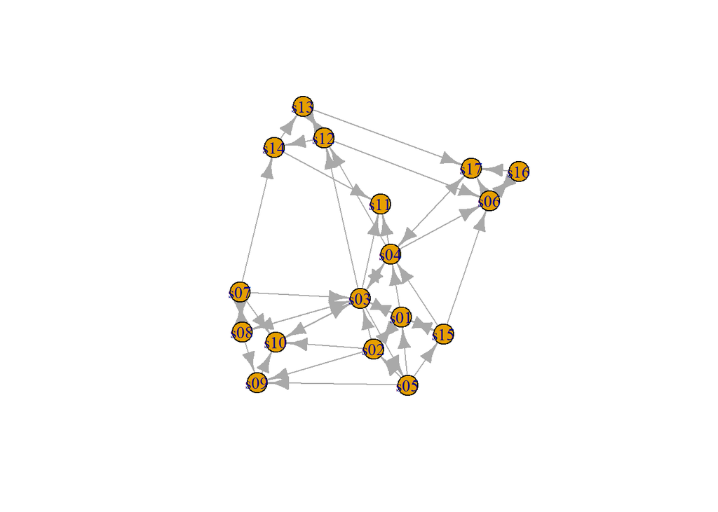

```r
plot(net) # a bit ugly
```

```r
find("simplify")
```

```
## [1] "package:igraph"
```

```r
net_simple <- igraph::simplify(
  net,
  remove.multiple = FALSE,
  remove.loops = TRUE
)

#if remove.multiple = TRUE
#simplify(
  #net,
  #remove.multiple = TRUE,
  #remove.loops = TRUE,
  #edge.attr.comb = list(weight = "sum", type = "ignore") #If there are multiple edges between A and B, these edges will be "merged" into one. For "weight" attribute, add the weights of multiple edges. For "type" attribute, discard them.
#)
```

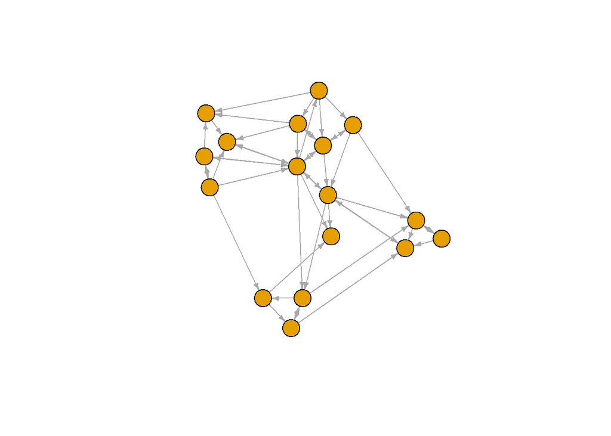

```r
# We can reduce the arrow size and remove the labels
plot(net_simple, edge.arrow.size=.4,vertex.label=NA) # a bit better
```

- Some overall indicators to describe the network
1. *Density*: Existing number of connections/Possible number of connections
- the degree of closeness of internal connections within a group
- if Density = 1, it means that all entities are connected

```r
edge_density(net, loops=F)
```

```
## [1] 0.1801471
```

2. *Average Path Length*: The average number of steps required between any two entities in the network
- The smaller this number is, the faster the information spreads in this network

```r
mean_distance(net, directed=T)
```

```
## [1] 27.55078
```

```r
avg_dist <- mean_distance(net, directed=T, weights=NA)
print(avg_dist)
```

```
## [1] 2.742188
```

3. *Diameter*: The shortest path length between the two farthest entities on the network

```r
diameter(net, directed=T, weights=NA)
```

```
## [1] 6
```

4. *Transitivity/Clustering Coefficient*: the degree to which nodes in a graph tend to cluster together

```r
#global transitivity: the number of closed triplets (or 3 x triangles) over the total number of triplets (both open and closed)
#closed triplets: A-B,B-C,A-C
#open triplets: A-B,B-C
transitivity(net, type="global")
```

```
## [1] 0.372549
```

```r
#local transitivity: The probability that the neighbors of a entity are themselves connected
transitivity(net, type="local")
```

```
##       s01       s02       s03       s04       s05       s06       s07       s08
## 0.6000000 0.6000000 0.2500000 0.3333333 0.5000000 0.4000000 0.3333333 0.3333333
##       s09       s10       s11       s12       s13       s14       s15       s16
## 0.3333333 0.5000000 0.3333333 0.3000000 0.3333333 0.1666667 0.5000000 1.0000000
##       s17
## 0.3333333
```

### Task for practice: Build a network and describe its overall characteristics

Please use the “Airlines” data

1. Building the network
2. Calculate the overall indicators
- Density
- Average Path Length
- Diameter
- Transitivity

### Node-level centrality measures

Centrality measures help us identify which nodes are more important in the network from different perspectives. Here we introduce four common node-level indicators: degree centrality, closeness centrality, betweenness centrality, and eigenvector centrality.

#### Degree centrality

Degree centrality measures how many direct connections a node has.

In a directed network, we can distinguish:

In-degree: how many ties a node receives

Out-degree: how many ties a node sends

Nodes with higher degree centrality are more directly connected to others.

```r
# degree centrality
deg_all <- degree(net, mode = "all")
deg_in  <- degree(net, mode = "in")
deg_out <- degree(net, mode = "out")

# combine into a table
degree_result <- data.frame(
  media = V(net)$media,
  degree_all = deg_all,
  degree_in = deg_in,
  degree_out = deg_out
)

degree_result
```

```
##                   media degree_all degree_in degree_out
## s01            NY Times          8         4          4
## s02     Washington Post          6         2          4
## s03 Wall Street Journal         13         6          7
## s04           USA Today          9         4          5
## s05            LA Times          5         1          4
## s06       New York Post          8         5          3
## s07                 CNN          5         1          4
## s08               MSNBC          5         2          3
## s09            FOX News          4         3          1
## s10                 ABC          5         4          1
## s11                 BBC          3         3          0
## s12          Yahoo News          6         3          3
## s13         Google News          4         2          2
## s14         Reuters.com          4         2          2
## s15         NYTimes.com          5         2          3
## s16  WashingtonPost.com          3         1          2
## s17             AOL.com          5         4          1
```

```r
# show the top nodes by total degree
degree_result[order(-degree_result$degree_all), ]
```

```
##                   media degree_all degree_in degree_out
## s03 Wall Street Journal         13         6          7
## s04           USA Today          9         4          5
## s01            NY Times          8         4          4
## s06       New York Post          8         5          3
## s02     Washington Post          6         2          4
## s12          Yahoo News          6         3          3
## s05            LA Times          5         1          4
## s07                 CNN          5         1          4
## s08               MSNBC          5         2          3
## s10                 ABC          5         4          1
## s15         NYTimes.com          5         2          3
## s17             AOL.com          5         4          1
## s09            FOX News          4         3          1
## s13         Google News          4         2          2
## s14         Reuters.com          4         2          2
## s11                 BBC          3         3          0
## s16  WashingtonPost.com          3         1          2
```

#### Closeness centrality

Closeness centrality measures how close a node is to all other nodes in the network based on shortest paths.

A node with high closeness centrality can reach other nodes more quickly.

This may indicate faster access to information in the network.

```r
# closeness centrality
close_out <- closeness(net, mode = "out", normalized = TRUE)
close_in  <- closeness(net, mode = "in", normalized = TRUE)

closeness_result <- data.frame(
  media = V(net)$media,
  closeness_out = close_out,
  closeness_in = close_in
)

closeness_result
```

```
##                   media closeness_out closeness_in
## s01            NY Times    0.03539823   0.04201681
## s02     Washington Post    0.05734767   0.02300613
## s03 Wall Street Journal    0.07920792   0.03978780
## s04           USA Today    0.04123711   0.04643963
## s05            LA Times    0.03818616   0.04065041
## s06       New York Post    0.02119205   0.09146341
## s07                 CNN    0.09248555   0.02013423
## s08               MSNBC    0.07142857   0.03448276
## s09            FOX News    0.02841918   0.04120879
## s10                 ABC    0.06896552   0.03797468
## s11                 BBC           NaN   0.05263158
## s12          Yahoo News    0.02377415   0.07692308
## s13         Google News    0.03661327   0.03080082
## s14         Reuters.com    0.02298851   0.03151261
## s15         NYTimes.com    0.04532578   0.02362205
## s16  WashingtonPost.com    0.02113606   0.03289474
## s17             AOL.com    0.03555556   0.04702194
```

```r
# show the top nodes by out-closeness
closeness_result[order(-closeness_result$closeness_out), ]
```

```
##                   media closeness_out closeness_in
## s07                 CNN    0.09248555   0.02013423
## s03 Wall Street Journal    0.07920792   0.03978780
## s08               MSNBC    0.07142857   0.03448276
## s10                 ABC    0.06896552   0.03797468
## s02     Washington Post    0.05734767   0.02300613
## s15         NYTimes.com    0.04532578   0.02362205
## s04           USA Today    0.04123711   0.04643963
## s05            LA Times    0.03818616   0.04065041
## s13         Google News    0.03661327   0.03080082
## s17             AOL.com    0.03555556   0.04702194
## s01            NY Times    0.03539823   0.04201681
## s09            FOX News    0.02841918   0.04120879
## s12          Yahoo News    0.02377415   0.07692308
## s14         Reuters.com    0.02298851   0.03151261
## s06       New York Post    0.02119205   0.09146341
## s16  WashingtonPost.com    0.02113606   0.03289474
## s11                 BBC           NaN   0.05263158
```

#### Betweenness centrality

Betweenness centrality measures how often a node lies on the shortest paths between other nodes.

Nodes with high betweenness may act as bridges or brokers.

They can play an important role in connecting different parts of the network.

```r
# betweenness centrality
btw <- betweenness(net, directed = TRUE, normalized = TRUE)

betweenness_result <- data.frame(
  media = V(net)$media,
  betweenness = btw
)

betweenness_result
```

```
##                   media betweenness
## s01            NY Times 0.073611111
## s02     Washington Post 0.004166667
## s03 Wall Street Journal 0.602083333
## s04           USA Today 0.404166667
## s05            LA Times 0.208333333
## s06       New York Post 0.089583333
## s07                 CNN 0.002083333
## s08               MSNBC 0.058333333
## s09            FOX News 0.004166667
## s10                 ABC 0.120833333
## s11                 BBC 0.000000000
## s12          Yahoo News 0.172916667
## s13         Google News 0.089583333
## s14         Reuters.com 0.004166667
## s15         NYTimes.com 0.019444444
## s16  WashingtonPost.com 0.000000000
## s17             AOL.com 0.275000000
```

```r
# show the top nodes by betweenness
betweenness_result[order(-betweenness_result$betweenness), ]
```

```
##                   media betweenness
## s03 Wall Street Journal 0.602083333
## s04           USA Today 0.404166667
## s17             AOL.com 0.275000000
## s05            LA Times 0.208333333
## s12          Yahoo News 0.172916667
## s10                 ABC 0.120833333
## s06       New York Post 0.089583333
## s13         Google News 0.089583333
## s01            NY Times 0.073611111
## s08               MSNBC 0.058333333
## s15         NYTimes.com 0.019444444
## s02     Washington Post 0.004166667
## s09            FOX News 0.004166667
## s14         Reuters.com 0.004166667
## s07                 CNN 0.002083333
## s11                 BBC 0.000000000
## s16  WashingtonPost.com 0.000000000
```

#### Eigenvector centrality

Eigenvector centrality measures not only how many connections a node has, but also how important its connected neighbors are.

A node connected to many well-connected nodes will have a higher eigenvector centrality.

This indicator captures influence or prestige in the network.

```r
# eigenvector centrality
eig <- eigen_centrality(net, directed = TRUE, scale = TRUE)

eigen_result <- data.frame(
  media = V(net)$media,
  eigenvector = eig$vector
)

eigen_result
```

```
##                   media eigenvector
## s01            NY Times  0.81788701
## s02     Washington Post  0.39618735
## s03 Wall Street Journal  1.00000000
## s04           USA Today  0.85658677
## s05            LA Times  0.02147987
## s06       New York Post  0.07178186
## s07                 CNN  0.04925562
## s08               MSNBC  0.10919556
## s09            FOX News  0.06337946
## s10                 ABC  0.13631710
## s11                 BBC  0.42749641
## s12          Yahoo News  0.11226338
## s13         Google News  0.07888985
## s14         Reuters.com  0.05728287
## s15         NYTimes.com  0.36105115
## s16  WashingtonPost.com  0.03237916
## s17             AOL.com  0.08547794
```

```r
# show the top nodes by eigenvector centrality
eigen_result[order(-eigen_result$eigenvector), ]
```

```
##                   media eigenvector
## s03 Wall Street Journal  1.00000000
## s04           USA Today  0.85658677
## s01            NY Times  0.81788701
## s11                 BBC  0.42749641
## s02     Washington Post  0.39618735
## s15         NYTimes.com  0.36105115
## s10                 ABC  0.13631710
## s12          Yahoo News  0.11226338
## s08               MSNBC  0.10919556
## s17             AOL.com  0.08547794
## s13         Google News  0.07888985
## s06       New York Post  0.07178186
## s09            FOX News  0.06337946
## s14         Reuters.com  0.05728287
## s07                 CNN  0.04925562
## s16  WashingtonPost.com  0.03237916
## s05            LA Times  0.02147987
```

Combine all centrality measures in one table

```r
centrality_result <- data.frame(
  media = V(net)$media,
  degree_all = degree(net, mode = "all"),
  degree_in = degree(net, mode = "in"),
  degree_out = degree(net, mode = "out"),
  closeness_out = closeness(net, mode = "out", normalized = TRUE),
  closeness_in = closeness(net, mode = "in", normalized = TRUE),
  betweenness = betweenness(net, directed = TRUE, normalized = TRUE),
  eigenvector = eigen_centrality(net, directed = TRUE, scale = TRUE)$vector
)

centrality_result
```

```
##                   media degree_all degree_in degree_out closeness_out
## s01            NY Times          8         4          4    0.03539823
## s02     Washington Post          6         2          4    0.05734767
## s03 Wall Street Journal         13         6          7    0.07920792
## s04           USA Today          9         4          5    0.04123711
## s05            LA Times          5         1          4    0.03818616
## s06       New York Post          8         5          3    0.02119205
## s07                 CNN          5         1          4    0.09248555
## s08               MSNBC          5         2          3    0.07142857
## s09            FOX News          4         3          1    0.02841918
## s10                 ABC          5         4          1    0.06896552
## s11                 BBC          3         3          0           NaN
## s12          Yahoo News          6         3          3    0.02377415
## s13         Google News          4         2          2    0.03661327
## s14         Reuters.com          4         2          2    0.02298851
## s15         NYTimes.com          5         2          3    0.04532578
## s16  WashingtonPost.com          3         1          2    0.02113606
## s17             AOL.com          5         4          1    0.03555556
##     closeness_in betweenness eigenvector
## s01   0.04201681 0.073611111  0.81788701
## s02   0.02300613 0.004166667  0.39618735
## s03   0.03978780 0.602083333  1.00000000
## s04   0.04643963 0.404166667  0.85658677
## s05   0.04065041 0.208333333  0.02147987
## s06   0.09146341 0.089583333  0.07178186
## s07   0.02013423 0.002083333  0.04925562
## s08   0.03448276 0.058333333  0.10919556
## s09   0.04120879 0.004166667  0.06337946
## s10   0.03797468 0.120833333  0.13631710
## s11   0.05263158 0.000000000  0.42749641
## s12   0.07692308 0.172916667  0.11226338
## s13   0.03080082 0.089583333  0.07888985
## s14   0.03151261 0.004166667  0.05728287
## s15   0.02362205 0.019444444  0.36105115
## s16   0.03289474 0.000000000  0.03237916
## s17   0.04702194 0.275000000  0.08547794
```

#### Visualize degree centrality

We can also use node size to reflect degree centrality in the graph.

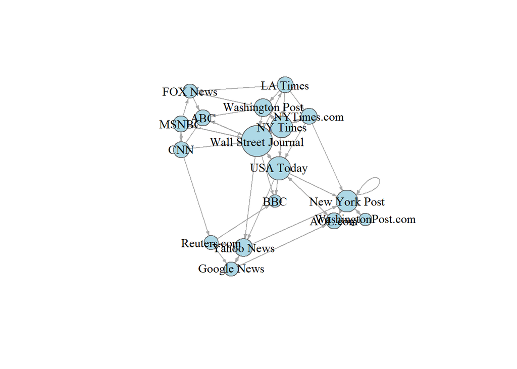

```r
V(net)$size <- degree(net, mode = "all") * 2 + 8
V(net)$label <- V(net)$media

plot(net,
     edge.arrow.size = .3,
     vertex.color = "lightblue",
     vertex.frame.color = "gray40",
     vertex.label.color = "black")
```

### Layout and highlighting

plotting parameters: we can set different parameters for nodes and edges, such as colors, shapes, sizes, and labels. To specify graphical parameters, we can supply name arguments to the plotting command `plot()`. Parameters for vertices start with prefix `vertex.`, parameters for edges have prefix `edge.` You can use `?igraph.plotting` to get more information about parameters.

```r
?igraph.plotting
```

- Step 1: Set parameters using `plot()` function

Plot with curved edges (`edge.curved=.1`) and reduce arrow size (`edge.arrow.size=.4`).

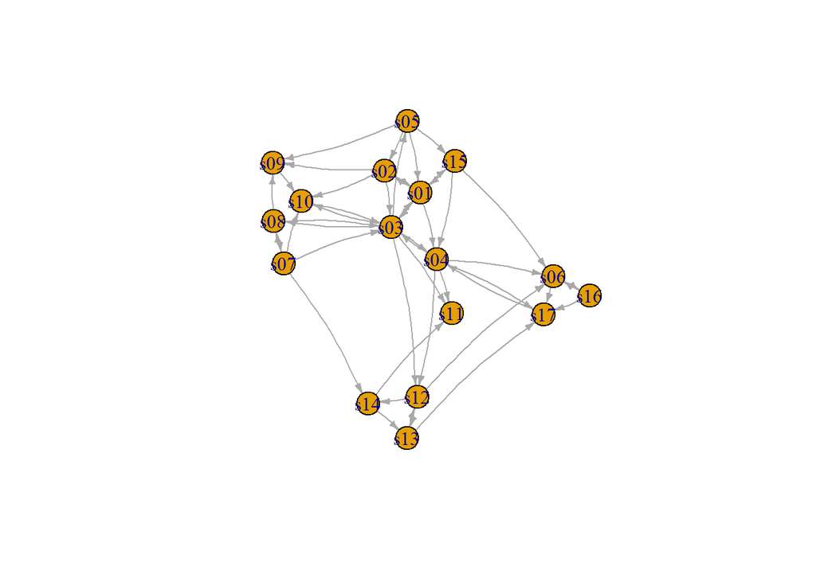

```r
plot(net_simple, edge.arrow.size=.4, edge.curved=.1)
```

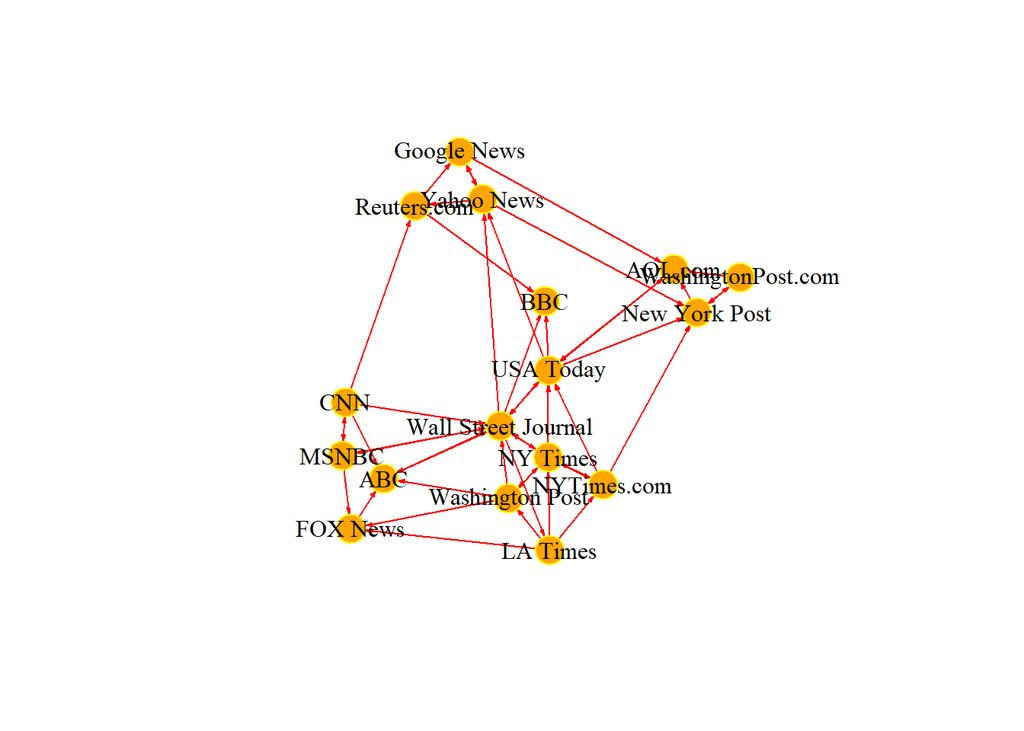

```r
plot(net_simple, edge.arrow.size=.2, edge.color="red",
     vertex.color="orange", vertex.frame.color="yellow", #set the border color of the nodes to white
     vertex.label=V(net_simple)$media, vertex.label.color="black")
```

### Task for practice: visualize net_simple and adjust parameters

in the following code chunk, plot the net_simple using `plot()` function. Set the edges as black with small arrows (.4). Set nodes to be blue with gray borders. Make each node to display a label from the variable `type.label`. Also adjust the labels to be yellow.

- Step 2: Network layouts

Network layouts are methods that decide the coordinates of each node, where each node should appear when we draw a network. To explore and demonstrate different layouts, we first create a 100-node graph using `sample_pa()`. Using this function, the computer will automatically generate a network showing 100 nodes and the edges (links between nodes. This graph is based on preferential attachment (Barabasi-Albert model).

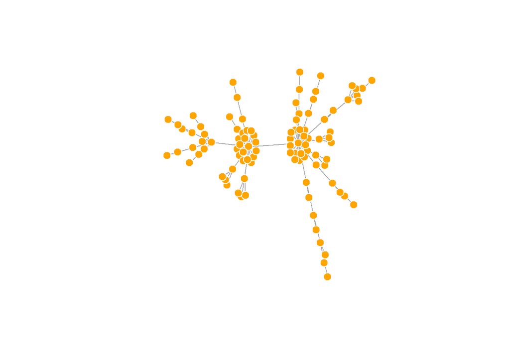

```r
net.bg <- sample_pa(100)  #create a network
V(net.bg)$size <- 8  #set the size of node to 8
V(net.bg)$frame.color <- "white" #set the border color
V(net.bg)$color <- "orange" #set the fill color of nodes
V(net.bg)$label <- ""  #remove node label
E(net.bg)$arrow.mode <- 0 #remove arrows for edges
plot(net.bg)
```

Next, we will introduce several layout types. first, `layout_randomly` helps place the nodes in random positions.`layout_in_circle` helps arrange all the nodes in a circle. `layout_on_sphere` calculates positions for each node as if the nodes were placed on the surface of a sphere (a 3D ball).

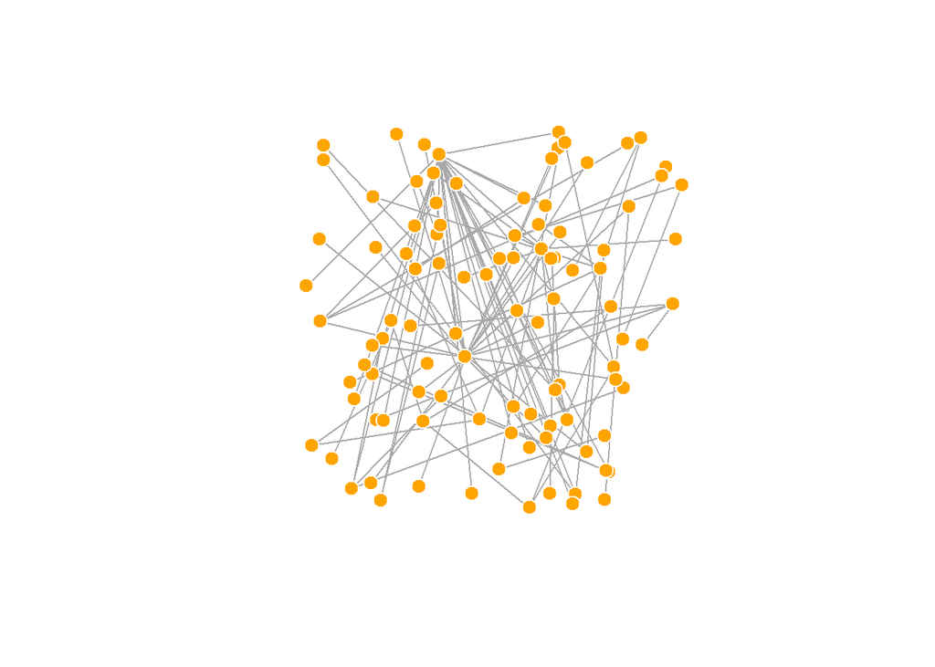

```r
#layout randomly
plot(net.bg, layout=layout_randomly)
```

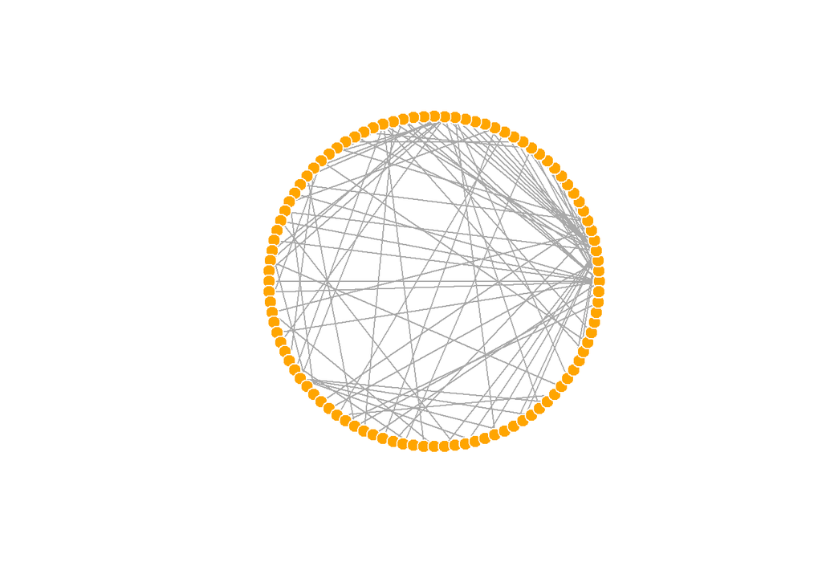

```r
#layout nodes in circle
l <- layout_in_circle(net.bg)
plot(net.bg, layout=l)
```

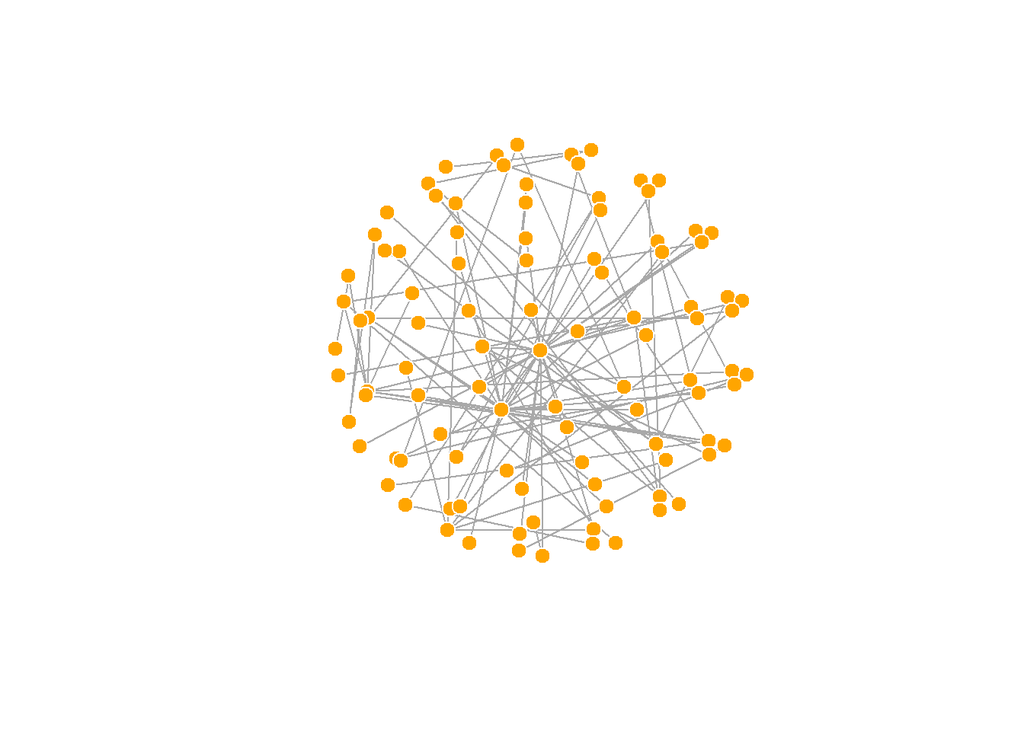

```r
#layout in 3d sphere
l <- layout_on_sphere(net.bg)
plot(net.bg, layout=l)
```

Fruchterman-Reingold is one of the most used force-directed layout algorithms out there. We can use `layout_with_fr()` to plot the graph. You can understand this function as to help us draw connected nodes closer to each other while unconnected nodes appear far from each other. Some other layout types include Kamada Kawai (kk), which is also a force directed algorithm. kk is similar to fr. The function used for kk is `layout_with_kk`. Another force-directed algorithm is GEM (`layout_with_gem`). Graphopt is another force directed algorithm, particularly helpful for visualizing large networks (`layout_with_graphopt`). The MDS (multidimensional scaling) algorithm is another layout type that places nodes that similar to and closer to each other closer together in the graph (`layout_with_mds`).

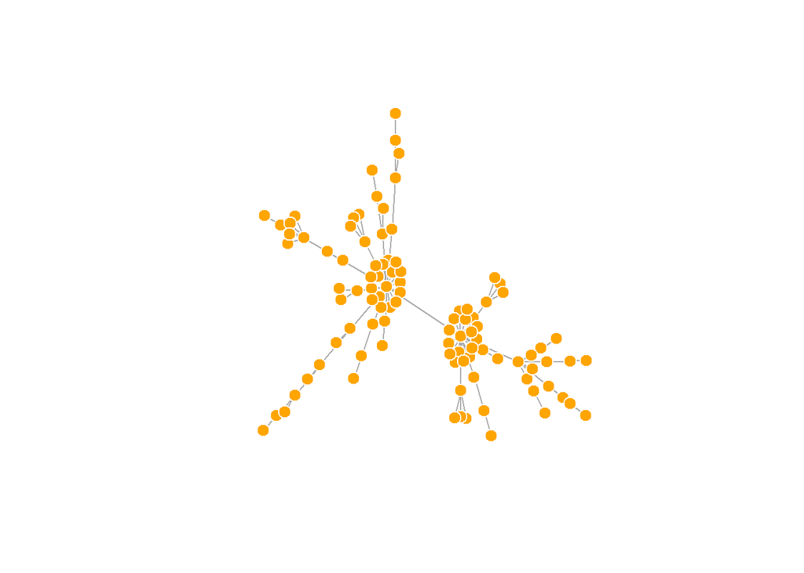

```r
#Fruchterman-Reingold layout
l <- layout_with_fr(net.bg)
plot(net.bg, layout=l)
```

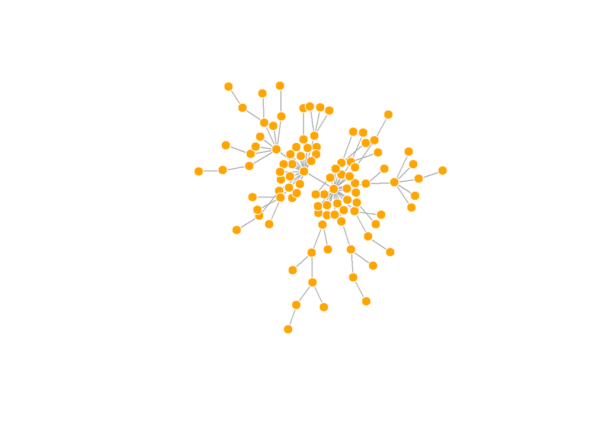

```r
#Kamada Kawai layout
l <- layout_with_kk(net.bg)
plot(net.bg, layout=l)
```

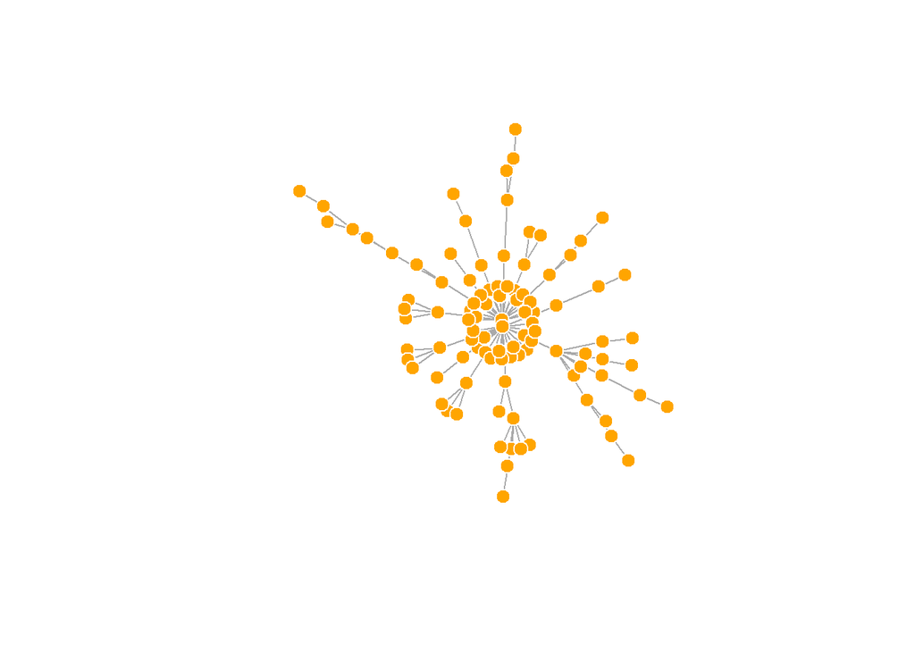

```r
#GEM layout
l <- layout_with_gem(net.bg)
plot(net.bg, layout=l)
```

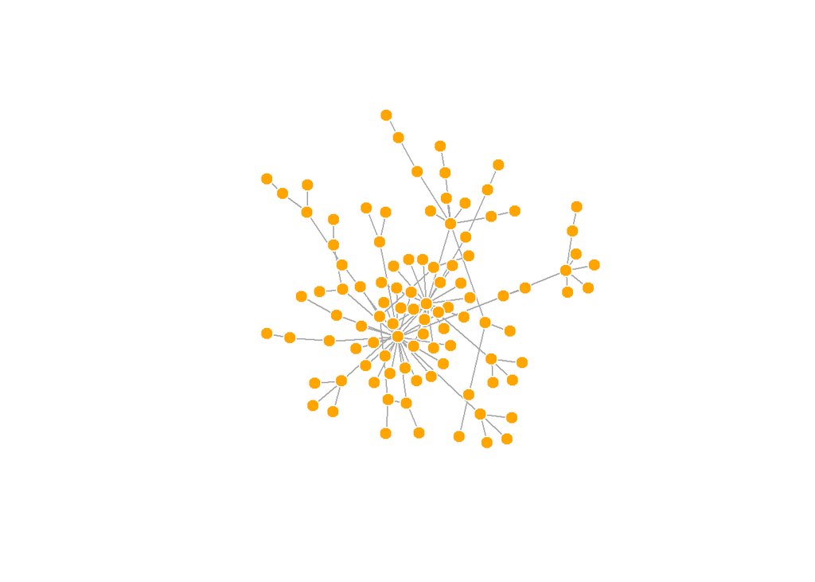

```r
#graphopt layout
l <- layout_with_graphopt(net.bg)
plot(net.bg, layout=l)
```

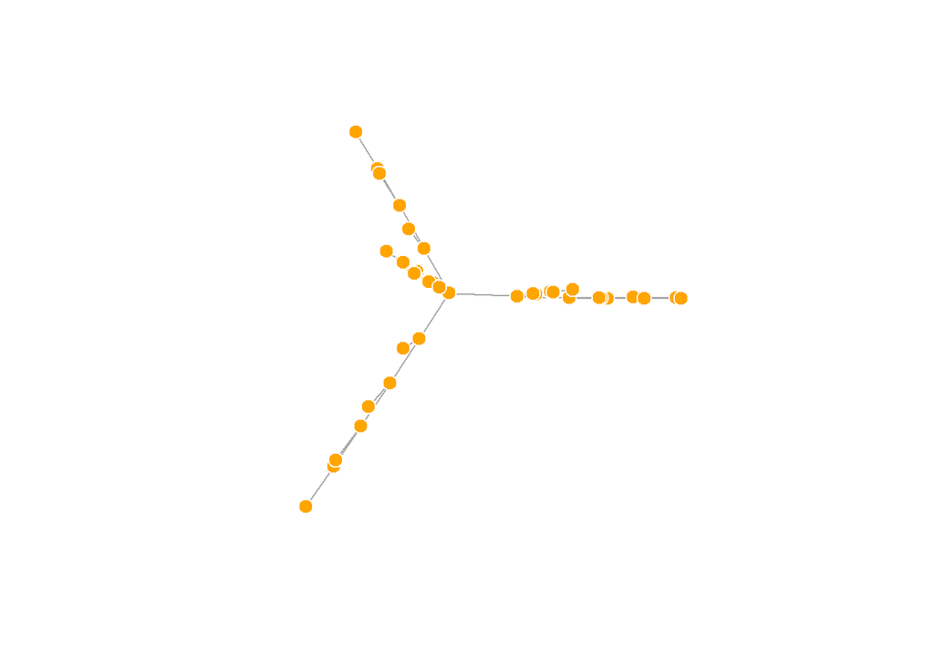

```r
#MDS layout
plot(net.bg, layout=layout_with_mds)
```

The following codes show all the avaiable layouts in igraph.

```
## [1] "layout_as_star"
```

```
## [1] "layout_components"
```

```
## [1] "layout_in_circle"
```

```
## [1] "layout_nicely"
```

```
## [1] "layout_on_grid"
```

```
## [1] "layout_on_sphere"
```

```
## [1] "layout_randomly"
```

```
## [1] "layout_with_dh"
```

```
## [1] "layout_with_drl"
```

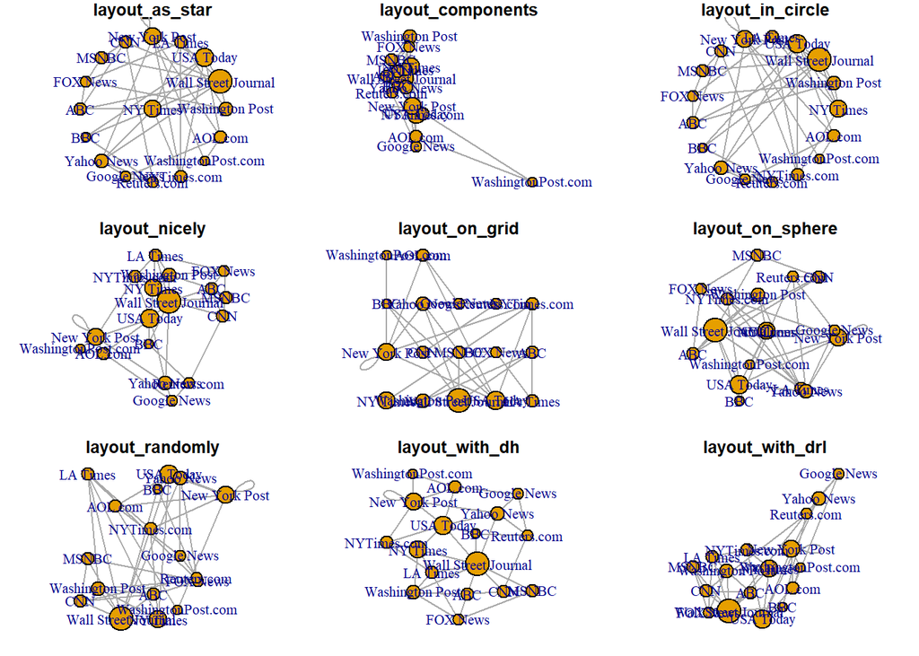

```
## [1] "layout_with_fr"
```

```
## [1] "layout_with_gem"
```

```
## [1] "layout_with_graphopt"
```

```
## [1] "layout_with_kk"
```

```
## [1] "layout_with_lgl"
```

```
## [1] "layout_with_mds"
```

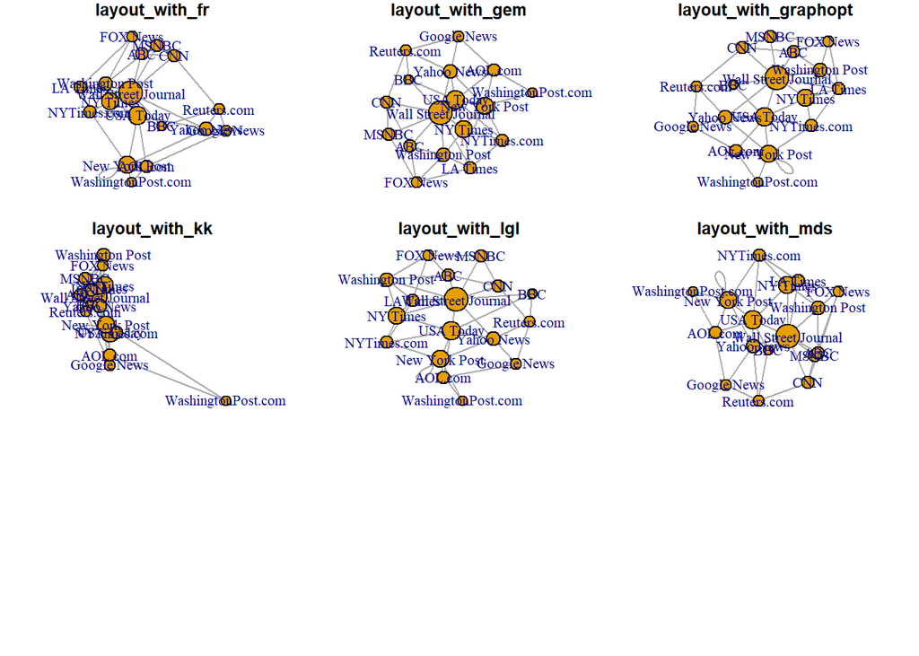

```r
layouts <- grep("^layout_", ls("package:igraph"), value=TRUE)[-1]
# Remove layouts that do not apply to our graph.
layouts <- layouts[!grepl("bipartite|merge|norm|sugiyama|tree", layouts)]

par(mfrow=c(3,3), mar=c(1,1,1,1))
for (layout in layouts) {
  print(layout)
  l <- do.call(layout, list(net))
  plot(net, edge.arrow.mode=0, layout=l, main=layout) }
```

- Step 3: Highlight networks If our network structure is too dense, we cannot observe it carefully and extract the most important information. Sometimes we just want to highlight the most important ties in the graph. The first way is to sparsify the network, keeping only the most important ties (that of higher weight).

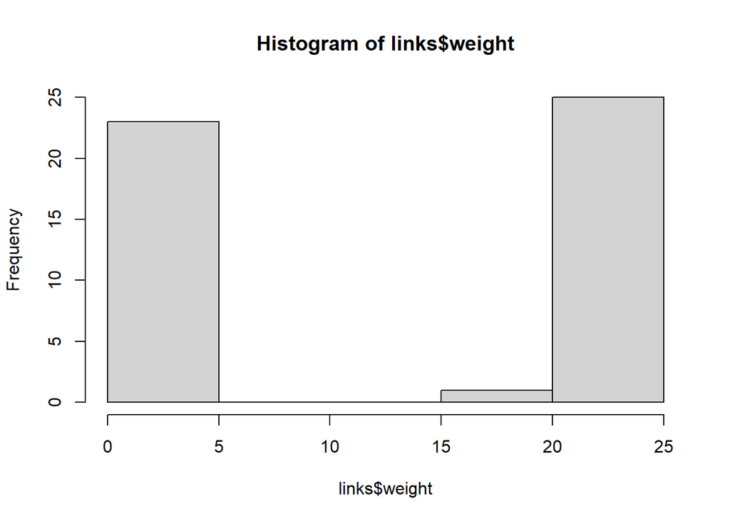

```r
hist(links$weight) #create a histogram of distribution of the weight
```

```r
mean(links$weight) #calculate the mean value of the weight
```

```
## [1] 12.40816
```

```r
sd(links$weight) #calculate the standard deviation of the weight
```

```
## [1] 9.905635
```

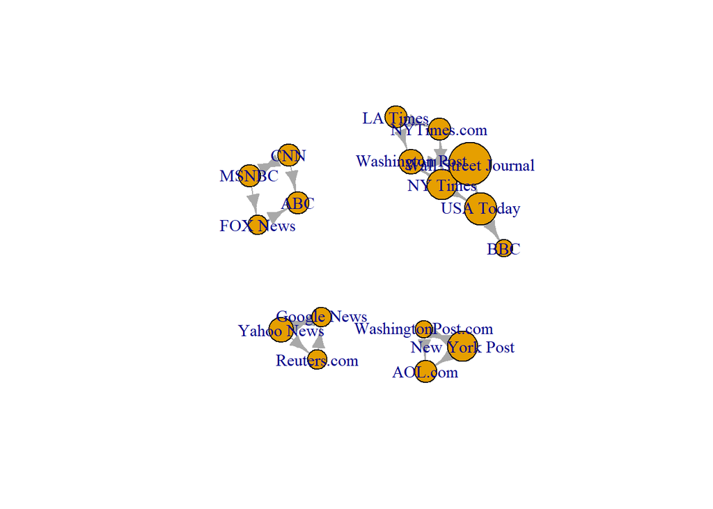

```r
# Here, we only keep edges that have weight higher than the mean for the network
cut.off <- mean(links$weight)
net.sp <- delete_edges(net, E(net)[weight<cut.off])
plot(net.sp, layout=layout_with_kk)
```

Another way to highlight part of networks is to highlight a group of particular nodes. Following is an example. In this example, we focus on NYT and visualize distances from NTY in the graph.

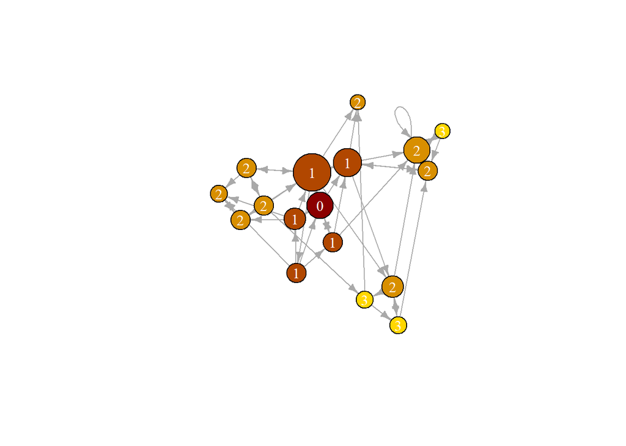

```r
#calculate distances from NYT node
dist.from.NYT <- distances(net, v=V(net)[media=="NY Times"],
                           to=V(net), weights=NA)

# Set colors to plot the distances:
oranges <- colorRampPalette(c("dark red", "gold")) #create a color scale from dark red to gold.
col <- oranges(max(dist.from.NYT)+1)
col <- col[dist.from.NYT+1] #assign colors to each node based on distances

plot(net, vertex.color=col, vertex.label=dist.from.NYT, edge.arrow.size=.6,
     vertex.label.color="white") #vertex.label shows the distance from NYT on each node.
```

Another way to highlight part of networks is to highlight a path in the network. The following codes demonstrate an example to find the shortest connection path between MSNBC and the New York Post and highlights it in the network graph

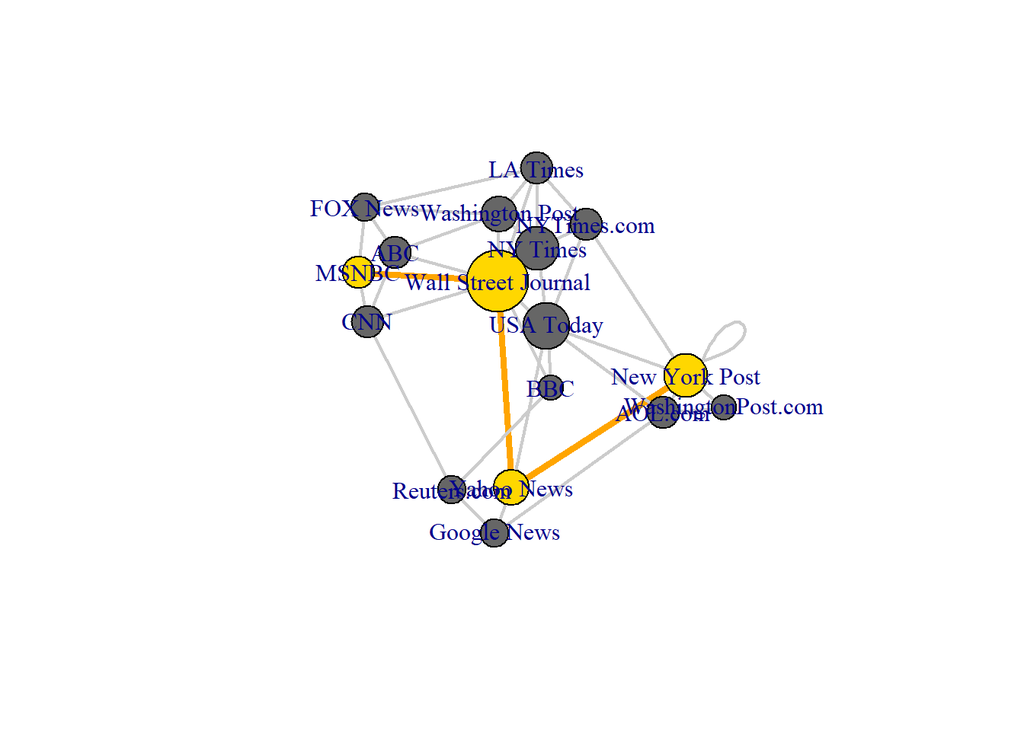

```r
#find the shortest path between MSNBC and New York Post.
news.path <- shortest_paths(net,
                            from = V(net)[media=="MSNBC"],
                             to  = V(net)[media=="New York Post"],
                             output = "both") # both path nodes and edges

# Generate edge color variable to plot the path:
ecol <- rep("gray80", ecount(net)) #all edges are colored light gray
ecol[unlist(news.path$epath)] <- "orange" #change the color of those edges on the shortest path to orange
# Generate edge width variable to plot the path:
ew <- rep(2, ecount(net)) #create default edge width
ew[unlist(news.path$epath)] <- 4 #make the path edge width thicker
# Generate node color variable to plot the path:
vcol <- rep("gray40", vcount(net)) #create default node colors
vcol[unlist(news.path$vpath)] <- "gold" #change the color of the nodes on path

plot(net, vertex.color=vcol, edge.color=ecol,
     edge.width=ew, edge.arrow.mode=0)
```

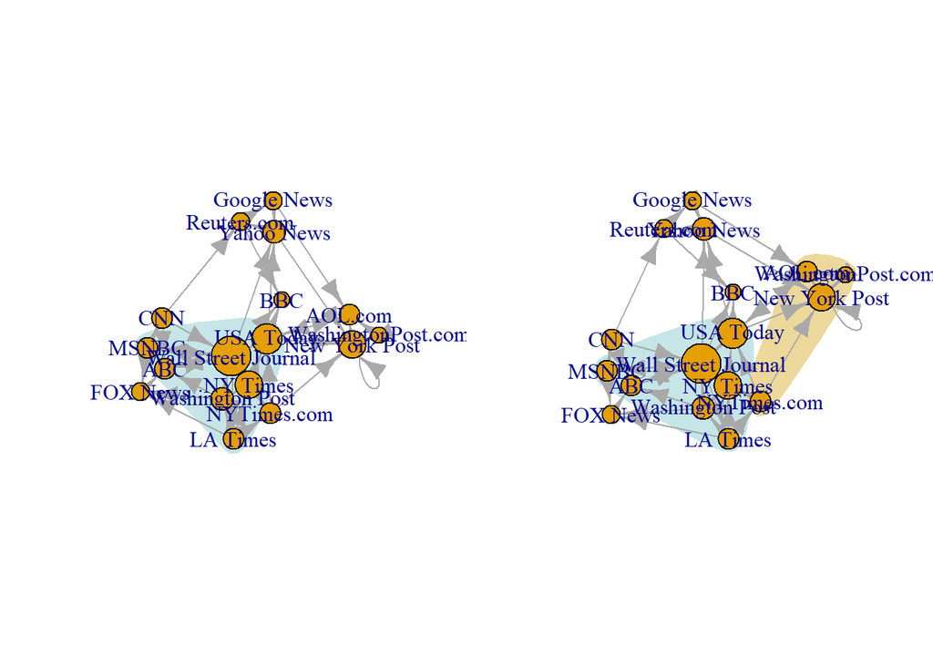

```r
par(mfrow=c(1,2)) #split the graph area into one row and two columns.
#mark one group
plot(net, mark.groups=c(1,4,5,8), mark.col="#C5E5E7", mark.border=NA) #highlight nodes 1,4,5,7 and cover them in light blue.

#mark two groups
plot(net, mark.groups=list(c(1,4,5,8), c(15:17)), #group nodes 1,4,5,8 and 15,17 separately.
          mark.col=c("#C5E5E7","#ECD89A"), mark.border=NA)
```